# QAIsoft — Sprint 2 | Análise multivariada e correção da Sprint 1

Equipe QAIsoft

## Objetivo

Corrigir os pontos indicados na avaliação da Sprint 1 e avançar para a análise multivariada de indicadores organizacionais de segurança, capacitação, uso de IA e produtividade. Os gráficos e as conclusões devem ser conferidos após executar o documento com os 17 CSVs originais.

## 1. Carregamento das bases

```r
library(tidyverse)
library(plotly)
# Ajuste o caminho abaixo para a pasta onde os 17 CSVs foram descompactados
setwd("C:/Users/pedro.perroni/OneDrive - ESPM/4° Semestre/Projeto Integrado")

billing = read_csv("ai_billing.csv")
budgets = read_csv("ai_budgets.csv")
licenses = read_csv("ai_licenses.csv")
models = read_csv("ai_models.csv")
tools = read_csv("ai_tools.csv")
usage.logs = read_csv("ai_usage_logs.csv")
tools.approved = read_csv("approved_ai_tools.csv")
builds = read_csv("builds.csv")
companies = read_csv("companies.csv")
departments = read_csv("departments.csv")
deployments = read_csv("deployments.csv")
employees = read_csv("employees.csv")
issues = read_csv("issues.csv")
projects = read_csv("projects.csv")
pull.requests = read_csv("pull_requests.csv")
training.records = read_csv("training_records.csv")
security_events = read_csv("security_events.csv")
```

## Escopo da análise

Os CSVs contêm **18 empresas**. A análise utiliza a base completa, mantendo `department_id` (não `department_name`) como identificador único de departamento — vários departamentos de empresas diferentes compartilham o mesmo nome (ex.: “Financeiro” existe em 18 empresas), então agrupar só pelo nome misturaria empresas distintas. A interpretação dos resultados é sobre o conjunto de empresas, não sobre uma empresa individual chamada QSOFT. Descompacte os 17 CSVs na mesma pasta do Rmd.

## 2. Conferência de estrutura e valores ausentes

Antes de excluir ou preencher dados, identificamos os valores ausentes. **Não substituímos todos os NA por zero**: um valor não registrado não equivale necessariamente a zero.

```r
dim(employees)
```

```
## [1] 2356    8
```

```r
dim(departments)
```

```
## [1] 161   3
```

```r
dim(security_events)
```

```
## [1] 69  9
```

```r
dim(training.records)
```

```
## [1] 1597   10
```

```r
dim(usage.logs)
```

```
## [1] 269515     15
```

```r
dim(pull.requests)
```

```
## [1] 5124   10
```

```r
names(employees)
```

```
## [1] "employee_id"   "company_id"    "department_id" "job_role"
## [5] "seniority"     "hire_date"     "cost_center"   "active"
```

```r
names(departments)
```

```
## [1] "department_id"   "company_id"      "department_name"
```

```r
names(security_events)
```

```
## [1] "event_id"     "company_id"   "employee_id"  "timestamp"    "ai_tool_id"
## [6] "event_type"   "severity"     "policy_id"    "action_taken"
```

```r
names(training.records)
```

```
##  [1] "training_id"       "employee_id"       "company_id"
##  [4] "course_name"       "course_category"   "enrollment_date"
##  [7] "completion_date"   "completion_status" "score"
## [10] "duration_hours"
```

```r
names(usage.logs)
```

```
##  [1] "usage_id"       "timestamp"      "employee_id"    "company_id"
##  [5] "department_id"  "ai_tool_id"     "model_id"       "application"
##  [9] "request_count"  "input_tokens"   "output_tokens"  "latency_ms"
## [13] "request_status" "project_id"     "cost_center"
```

```r
colSums(is.na(employees))
```

```
##   employee_id    company_id department_id      job_role     seniority
##             0             0             0             0             0
##     hire_date   cost_center        active
##             0            45             0
```

```r
colSums(is.na(security_events))
```

```
##     event_id   company_id  employee_id    timestamp   ai_tool_id   event_type
##            0            0            0            0            0            0
##     severity    policy_id action_taken
##            0            0            0
```

```r
colSums(is.na(training.records))
```

```
##       training_id       employee_id        company_id       course_name
##                 0                 0                 0                 0
##   course_category   enrollment_date   completion_date completion_status
##                 0                 0                 0                 0
##             score    duration_hours
##                 0                 0
```

```r
colSums(is.na(usage.logs))
```

```
##       usage_id      timestamp    employee_id     company_id  department_id
##              0              0              0              0              0
##     ai_tool_id       model_id    application  request_count   input_tokens
##              0              0              0              0              0
##  output_tokens     latency_ms request_status     project_id    cost_center
##              0              0              0         206909           6924
```

```r
colSums(is.na(pull.requests))
```

```
## pull_request_id      project_id     employee_id      created_at       merged_at
##               0               0               0               0               0
##          status   files_changed       additions       deletions    review_count
##               0               0               0               0               0
```

**Decisão metodológica (resposta direta ao feedback “que tipo de preenchimento de dados vocês realizaram?”):** mantivemos as bases originais intactas e **não aplicamos nenhuma imputação automática** (não substituímos NA por média, mediana ou zero). Quando uma análise exige dados completos em uma variável específica, as linhas com ausência nessa variável são excluídas pontualmente com `drop_na()`, e o número de linhas excluídas é registrado. A única exceção é quando a ausência de registro é, por definição do negócio, equivalente a “zero eventos” (por exemplo: um departamento sem nenhuma pull request registrada tem 0 entregas, não um valor desconhecido) — nesses casos específicos, documentados em cada seção, convertemos a ausência de linha em 0.

## 3. Quais são os indicadores organizacionais?

Resposta direta ao feedback: os indicadores usados neste relatório, por departamento, são:

- **funcionarios** — número de funcionários alocados no departamento.
- **incidentes** — número de eventos de segurança (`security_events`) ligados a funcionários do departamento.
- **incidentes_graves** — subconjunto dos incidentes com severidade “Alta” ou “Critica”.
- **requisicoes_ia** — soma de `request_count` nos logs de uso de IA (`ai_usage_logs`) do departamento.
- **entregas** — número de pull requests (`pull_requests`) abertas por funcionários do departamento.
- **taxa_treinamento** — proporção de funcionários do departamento com ao menos um treinamento concluído (`completion_status == "Concluido"`).
- **incidentes_por_funcionario** e **entregas_por_funcionario** — taxas que normalizam os indicadores de contagem pelo tamanho do departamento, para permitir comparação entre departamentos de tamanhos diferentes.

```r
# Quantidade de funcionários por departamento
funcionarios_area = employees %>%
  group_by(department_id) %>%
  summarise(funcionarios = n(), .groups = "drop")

# Quantidade de incidentes por departamento
incidentes_area = security_events %>%
  left_join(select(employees, employee_id, department_id), by = "employee_id") %>%
  group_by(department_id) %>%
  summarise(incidentes = n(), .groups = "drop")

# Quantidade de requisições de IA por departamento
uso_area = usage.logs %>%
  group_by(department_id) %>%
  summarise(requisicoes_ia = sum(request_count, na.rm = TRUE),
            latencia_media = mean(latency_ms, na.rm = TRUE),
            .groups = "drop")

# Quantidade de pull requests por departamento
entregas_area = pull.requests %>%
  left_join(select(employees, employee_id, department_id), by = "employee_id") %>%
  group_by(department_id) %>%
  summarise(entregas = n(), .groups = "drop")

# Taxa de treinamento concluído por departamento
treino_area = training.records %>%
  filter(completion_status == "Concluido") %>%
  left_join(select(employees, employee_id, department_id), by = "employee_id") %>%
  distinct(employee_id, department_id) %>%
  group_by(department_id) %>%
  summarise(func_treino_concluido = n(), .groups = "drop")

# Quadro de indicadores. Ausência de linha em incidentes/entregas/requisições
# significa "nenhum evento registrado" (0), por definição do negócio; por isso
# convertemos essas ausências para 0 (não são valores desconhecidos). Já
# "funcionarios" e "latencia_media" permanecem NA quando não há como calculá-los.
indicadores = departments %>%
  select(department_id, department_name, company_id) %>%
  left_join(funcionarios_area, by = "department_id") %>%
  left_join(incidentes_area, by = "department_id") %>%
  left_join(uso_area, by = "department_id") %>%
  left_join(entregas_area, by = "department_id") %>%
  left_join(treino_area, by = "department_id") %>%
  mutate(incidentes = replace_na(incidentes, 0),
         requisicoes_ia = replace_na(requisicoes_ia, 0),
         entregas = replace_na(entregas, 0),
         func_treino_concluido = replace_na(func_treino_concluido, 0),
         taxa_treinamento = func_treino_concluido / funcionarios,
         incidentes_por_funcionario = incidentes / funcionarios,
         entregas_por_funcionario = entregas / funcionarios)

print(head(indicadores, 10))
```

```
## # A tibble: 10 × 12
##    department_id department_name         company_id funcionarios incidentes
##    <chr>         <chr>                   <chr>             <int>      <int>
##  1 C01-D01       Engenharia de Software  C01                 114          1
##  2 C01-D02       DevOps e Infraestrutura C01                  33          0
##  3 C01-D03       Produto                 C01                  19          0
##  4 C01-D04       Qualidade (QA)          C01                  39          1
##  5 C01-D05       Dados e Analytics       C01                  23          1
##  6 C01-D06       Vendas                  C01                  46          0
##  7 C01-D07       Marketing               C01                  14          0
##  8 C01-D08       Suporte ao Cliente      C01                  42          1
##  9 C01-D09       RH                      C01                  13          0
## 10 C01-D10       Financeiro              C01                  17          0
## # ℹ 7 more variables: requisicoes_ia <dbl>, latencia_media <dbl>,
## #   entregas <int>, func_treino_concluido <int>, taxa_treinamento <dbl>,
## #   incidentes_por_funcionario <dbl>, entregas_por_funcionario <dbl>
```

**Atenção:** o número de incidentes não é a quantidade de funcionários que cometeram infrações (um funcionário pode gerar mais de um evento). A taxa de incidentes por funcionário mede eventos por funcionário, não a proporção de funcionários infratores. Departamentos com `funcionarios` ausente (sem funcionários cadastrados) não entram nas taxas.

## 4. Quais departamentos concentram as infrações de segurança mais graves?

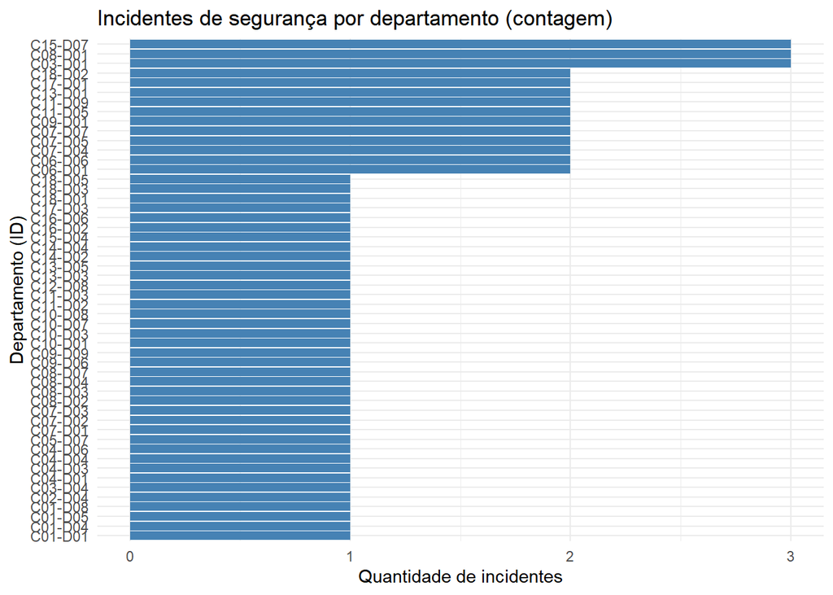

```r
ggplot(incidentes_area, aes(x = fct_reorder(department_id, incidentes), y = incidentes)) +
  geom_col(fill = "steelblue") +
  coord_flip() +
  labs(title = "Incidentes de segurança por departamento (contagem)",
       x = "Departamento (ID)", y = "Quantidade de incidentes") +
  theme_minimal()
```

**Interpretação:** o gráfico acima mostra quantidade, não gravidade, e está ordenado apenas para leitura (não é uma variável ordinal). O gráfico abaixo apresenta a composição percentual das severidades **por departamento único** (`department_id`), rotulado com nome do departamento e empresa para evitar misturar, por exemplo, o “Financeiro” de 18 empresas diferentes em uma única barra.

```r
base_gravidade = security_events %>%
  select(-company_id) %>%  # evita conflito: departments também tem company_id
  left_join(select(employees, employee_id, department_id), by = "employee_id") %>%
  left_join(select(departments, department_id, department_name, company_id), by = "department_id") %>%
  mutate(dept_label = paste0(department_name, " (", company_id, ")"),
         # Severidade também é ordinal: a ordem não pode ser alfabética
         severity = factor(severity, levels = c("Baixa", "Media", "Alta", "Critica")))

# Ordena os departamentos por volume total de incidentes só para a leitura do
# eixo (ranking de magnitude, não é o caso de uma variável ordinal como severidade)
ordem_departamentos = base_gravidade %>% count(dept_label, sort = TRUE) %>% pull(dept_label)
base_gravidade = base_gravidade %>% mutate(dept_label = factor(dept_label, levels = rev(ordem_departamentos)))

grafico_gravidade = ggplot(base_gravidade, aes(x = dept_label, fill = severity)) +
  geom_bar(position = "fill") +
  coord_flip() +
  scale_fill_manual(values = c("Baixa" = "#c7e9c0", "Media" = "#fdd0a2",
                                "Alta" = "#fc9272", "Critica" = "#de2d26")) +
  labs(title = "Composição dos incidentes por gravidade e departamento",
       x = "Departamento (empresa)", y = "Proporção dos incidentes", fill = "Gravidade") +
  theme_minimal()

plotly::ggplotly(grafico_gravidade)
```

[interactive chart not shown]

```r
# Incidentes graves = Alta ou Critica, por departamento único (id + empresa)
incidentes_graves = base_gravidade %>%
  filter(severity %in% c("Alta", "Critica")) %>%
  count(dept_label, name = "incidentes_graves") %>%
  arrange(desc(incidentes_graves))
print(incidentes_graves)
```

```
## # A tibble: 18 × 2
##    dept_label                     incidentes_graves
##    <fct>                                      <int>
##  1 Operacoes de Loja (C13)                        2
##  2 Operacoes Bancarias (C06)                      2
##  3 Criacao (C17)                                  2
##  4 Atendimento ao Cliente (C07)                   2
##  5 Tecnologia da Informacao (C16)                 1
##  6 RH (C12)                                       1
##  7 Qualidade (QA) (C02)                           1
##  8 Producao (C10)                                 1
##  9 Marketing (C14)                                1
## 10 Marketing (C05)                                1
## 11 Logistica e Supply Chain (C14)                 1
## 12 Logistica (C11)                                1
## 13 Engenharia de Software (C04)                   1
## 14 E-commerce (C13)                               1
## 15 Comercial (C09)                                1
## 16 Tecnologia da Informacao (C11)                 1
## 17 Engenharia de Software (C03)                   1
## 18 Consultoria e Projetos (C15)                   1
```

A base de eventos de segurança tem apenas 69 registros no total, espalhados por 52 departamentos distintos — a maioria com 1 ou 2 eventos. Por isso, proporções de 100% devem ser lidas junto ao número absoluto de eventos: departamentos com poucos eventos podem apresentar percentuais extremos sem representar um padrão robusto.

## 5. Existe gargalo de capacitação?

A distribuição de horas por **registro de treinamento** é diferente de horas totais por funcionário. Portanto, não concluímos que a empresa possui gargalo apenas olhando o histograma.

```r
# Um único histograma, sem duplicação
base_treino = training.records %>%
  select(duration_hours) %>%
  drop_na()

grafico_treino = ggplot(base_treino, aes(x = duration_hours)) +
  geom_histogram(bins = 10, fill = "steelblue", color = "white") +
  labs(title = "Distribuição da duração dos registros de treinamento",
       x = "Duração (horas)", y = "Quantidade de registros") +
  theme_minimal()

plotly::ggplotly(grafico_treino)
```

[interactive chart not shown]

```r
# Funcionários com pelo menos um registro de treinamento
funcionarios_treinados = training.records %>% select(employee_id) %>% distinct()

# Funcionários sem registros de treinamento (indicador de cobertura)
cobertura_treino = employees %>%
  mutate(com_registro_treino = ifelse(employee_id %in% funcionarios_treinados$employee_id,
                                       "Com registro", "Sem registro"))

resumo_cobertura = cobertura_treino %>%
  count(com_registro_treino) %>%
  mutate(pct = round(100 * n / sum(n), 1))
print(resumo_cobertura)
```

```
## # A tibble: 2 × 3
##   com_registro_treino     n   pct
##   <chr>               <int> <dbl>
## 1 Com registro         1056  44.8
## 2 Sem registro         1300  55.2
```

```r
grafico_cobertura = ggplot(resumo_cobertura, aes(x = com_registro_treino, y = pct, fill = com_registro_treino)) +
  geom_col(width = 0.5) +
  labs(title = "Cobertura de registros de treinamento",
       x = NULL, y = "% de funcionários") +
  theme_minimal() + theme(legend.position = "none")

plotly::ggplotly(grafico_cobertura)
```

[interactive chart not shown]

## 6. Senioridade e incidentes: respeitando a ordem ordinal

```r
# Confira primeiro os valores reais da base:
unique(employees$seniority)
```

```
## [1] "Pleno"        "Junior"       "Senior"       "Especialista" "Gerente"
```

```r
# Ordem ordinal real dos níveis de senioridade (conferida contra os dados:
# "Junior","Pleno","Senior","Especialista","Gerente")
ordem_senioridade = c("Junior", "Pleno", "Senior", "Especialista", "Gerente")

base_senioridade = security_events %>%
  left_join(select(employees, employee_id, seniority), by = "employee_id") %>%
  drop_na(seniority) %>%
  mutate(seniority = factor(seniority, levels = ordem_senioridade))

# Antes de interpretar, confirme que não há categorias transformadas em NA
# (apareceria como <NA> abaixo se algum nível da base não estivesse na lista)
print(table(base_senioridade$seniority, useNA = "ifany"))
```

```
##
##       Junior        Pleno       Senior Especialista      Gerente
##           24           23           17            1            4
```

```r
grafico_senioridade = ggplot(base_senioridade, aes(x = seniority)) +
  geom_bar(fill = "steelblue") +
  labs(title = "Incidentes por senioridade (ordem ordinal natural)",
       x = "Senioridade", y = "Quantidade de incidentes") +
  theme_minimal()

plotly::ggplotly(grafico_senioridade)
```

[interactive chart not shown]

**Interpretação:** números absolutos não indicam que uma senioridade é mais arriscada; é necessário comparar com a quantidade de funcionários de cada categoria (ver `employees %>% count(seniority)`), já que níveis com mais funcionários tendem a concentrar mais eventos só pelo volume.

## 7. Uso de IA e produtividade: gráfico de dispersão

```r
base_produtividade = indicadores %>%
  select(department_id, dept_label = department_name, requisicoes_ia, entregas) %>%
  drop_na()

grafico_disp = ggplot(base_produtividade,
                       aes(x = requisicoes_ia, y = entregas,
                           text = paste("Departamento:", dept_label))) +
  geom_point(color = "steelblue", alpha = 0.6) +
  geom_smooth(method = "lm", se = FALSE, color = "red") +
  labs(title = "Uso de IA e volume de pull requests por departamento",
       x = "Quantidade de requisições de IA",
       y = "Quantidade de pull requests") +
  theme_minimal()

plotly::ggplotly(grafico_disp, tooltip = "text")
```

[interactive chart not shown]

```r
# Correlação, se houver variação em ambas as variáveis:
if (nrow(base_produtividade) >= 3 &&
    sd(base_produtividade$requisicoes_ia) > 0 &&
    sd(base_produtividade$entregas) > 0) {
  print(round(cor(base_produtividade$requisicoes_ia,
                   base_produtividade$entregas), 2))
}
```

```
## [1] 0.96
```

## 8. Shadow IT: uso de ferramentas não aprovadas

```r
# Atenção: esta comparação pressupõe que a lista de aprovadas é válida para a
# empresa/período analisado (a aprovação depende de company_id e ai_tool_id).
lista_aprovadas = tools.approved %>%
  filter(approval_status == "Aprovado") %>%
  select(company_id, ai_tool_id) %>%
  distinct() %>%
  mutate(aprovada = "Sim")

base_shadow = usage.logs %>%
  left_join(lista_aprovadas, by = c("company_id", "ai_tool_id")) %>%
  mutate(status = ifelse(is.na(aprovada), "Sem aprovação confirmada", "Ferramenta aprovada"))

resumo_shadow = base_shadow %>%
  count(status) %>%
  mutate(pct = round(100 * n / sum(n), 1))
print(resumo_shadow)
```

```
## # A tibble: 2 × 3
##   status                        n   pct
##   <chr>                     <int> <dbl>
## 1 Ferramenta aprovada      232913  86.4
## 2 Sem aprovação confirmada  36602  13.6
```

```r
grafico_shadow = ggplot(resumo_shadow, aes(x = status, y = pct, fill = status)) +
  geom_col(width = 0.5) +
  labs(title = "Uso de ferramentas na lista de aprovação",
       x = NULL, y = "% de requisições") +
  theme_minimal() + theme(legend.position = "none")

plotly::ggplotly(grafico_shadow)
```

[interactive chart not shown]

**Interpretação:** estar fora da lista consultada é um sinal para investigar, mas a classificação definitiva de Shadow IT depende das regras de aprovação por empresa e período.

## 9. Latência: boxplot por ferramenta

```r
base_latencia = usage.logs %>%
  left_join(select(tools, ai_tool_id, tool_name), by = "ai_tool_id") %>%
  select(tool_name, latency_ms) %>%
  drop_na()

grafico_latencia = ggplot(base_latencia, aes(x = tool_name, y = latency_ms)) +
  geom_boxplot(fill = "steelblue") +
  labs(title = "Distribuição da latência por ferramenta de IA",
       x = "Ferramenta", y = "Latência (ms)") +
  theme_minimal() +
  theme(axis.text.x = element_text(angle = 45, hjust = 1))

plotly::ggplotly(grafico_latencia)
```

[interactive chart not shown]

Pontos isolados representam observações atípicas segundo o critério do boxplot; não significam automaticamente falhas do sistema.

## 10. Capacitação concluída: indicador complementar

```r
concluidos = training.records %>%
  filter(completion_status == "Concluido") %>%
  select(employee_id) %>%
  distinct()

cobertura_concluida = employees %>%
  mutate(concluiu_treinamento = ifelse(employee_id %in% concluidos$employee_id,
                                        "Concluiu ao menos um", "Sem conclusão registrada"))

contagem_conclusao = table(cobertura_concluida$concluiu_treinamento)
porcentagem_conclusao = round(prop.table(contagem_conclusao) * 100, 1)
print(cbind(contagem_conclusao, porcentagem_conclusao))
```

```
##                          contagem_conclusao porcentagem_conclusao
## Concluiu ao menos um                    745                  31.6
## Sem conclusão registrada               1611                  68.4
```

Este indicador mede conclusão de ao menos um curso, não proficiência nem eficácia do treinamento.

## 11. Análise multivariada: correlação e regressão múltipla

Esta seção substitui o que na Sprint 1 era apenas uma promessa de análise futura. A unidade de análise é o **departamento** (`department_id`), e a ausência de registro em incidentes/requisições/entregas foi tratada como 0 (seção 3), por ser o significado correto desses dados — não uma imputação estatística.

### 11.1 Matriz de correlação

```r
base_multivariada = indicadores %>%
  select(funcionarios, incidentes, requisicoes_ia, entregas, taxa_treinamento, latencia_media) %>%
  drop_na()

matriz_cor = round(cor(base_multivariada), 2)
print(matriz_cor)
```

```
##                  funcionarios incidentes requisicoes_ia entregas
## funcionarios             1.00       0.19           0.45     0.40
## incidentes               0.19       1.00           0.08     0.04
## requisicoes_ia           0.45       0.08           1.00     0.96
## entregas                 0.40       0.04           0.96     1.00
## taxa_treinamento        -0.01      -0.13           0.16     0.12
## latencia_media           0.01       0.00          -0.38    -0.33
##                  taxa_treinamento latencia_media
## funcionarios                -0.01           0.01
## incidentes                  -0.13           0.00
## requisicoes_ia               0.16          -0.38
## entregas                     0.12          -0.33
## taxa_treinamento             1.00          -0.35
## latencia_media              -0.35           1.00
```

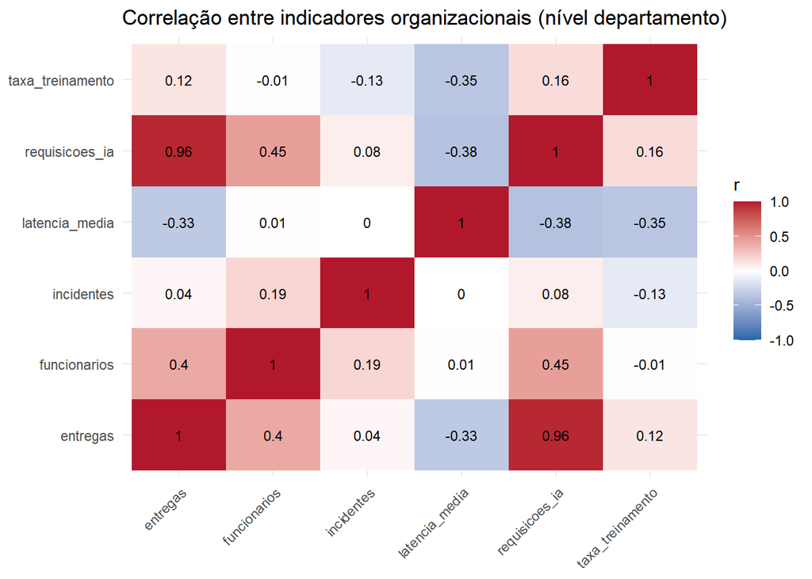

```r
matriz_cor_long = as.data.frame(matriz_cor) %>%
  mutate(var1 = rownames(matriz_cor)) %>%
  pivot_longer(-var1, names_to = "var2", values_to = "correlacao")

ggplot(matriz_cor_long, aes(x = var1, y = var2, fill = correlacao)) +
  geom_tile() +
  geom_text(aes(label = correlacao), size = 3) +
  scale_fill_gradient2(low = "#2166ac", mid = "white", high = "#b2182b", midpoint = 0, limits = c(-1, 1)) +
  labs(title = "Correlação entre indicadores organizacionais (nível departamento)",
       x = NULL, y = NULL, fill = "r") +
  theme_minimal() +
  theme(axis.text.x = element_text(angle = 45, hjust = 1))
```

### 11.2 Regressão linear múltipla

Pergunta de negócio (retomando a Sprint 1): **equipes que usam mais IA entregam mais, controlando pelo tamanho do time e pela capacitação?**

```r
modelo_entregas = lm(entregas ~ requisicoes_ia + funcionarios + taxa_treinamento,
                      data = base_multivariada)
summary(modelo_entregas)
```

```
##
## Call:
## lm(formula = entregas ~ requisicoes_ia + funcionarios + taxa_treinamento,
##     data = base_multivariada)
##
## Residuals:
##      Min       1Q   Median       3Q      Max
## -235.287   -5.769    4.603   12.828  118.985
##
## Coefficients:
##                    Estimate Std. Error t value Pr(>|t|)
## (Intercept)      -2.391e+00  7.448e+00  -0.321   0.7487
## requisicoes_ia    9.150e-04  2.365e-05  38.686   <2e-16 ***
## funcionarios     -4.216e-01  1.984e-01  -2.125   0.0354 *
## taxa_treinamento -2.655e+01  1.763e+01  -1.505   0.1346
## ---
## Signif. codes:  0 '***' 0.001 '**' 0.01 '*' 0.05 '.' 0.1 ' ' 1
##
## Residual standard error: 43.76 on 134 degrees of freedom
## Multiple R-squared:  0.932,  Adjusted R-squared:  0.9305
## F-statistic: 612.2 on 3 and 134 DF,  p-value: < 2.2e-16
```

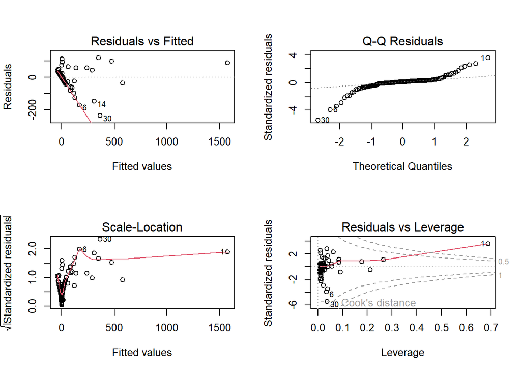

```r
par(mfrow = c(2, 2))
plot(modelo_entregas)
```

```r
par(mfrow = c(1, 1))
```